# Survival Analysis Tutorial

Vilija Joyce (via emilyzabor.com)

20220312

## Create example dataset with start and follow-up dates

tibble is like a data.frame (part of tidyverse package)

```r
test1 <-
  tibble(
    sx_date = c("2007-06-22", "2004-02-13", "2010-10-27"),
    last_fup_date = c("2017-04-15", "2018-07-04", "2016-10-31")
  )
```

Ck

```r
glimpse(test1)
```

```
## Rows: 3
## Columns: 2
## $ sx_date       <chr> "2007-06-22", "2004-02-13", "2010-10-27"
## $ last_fup_date <chr> "2017-04-15", "2018-07-04", "2016-10-31"
```

```r
test1
```

```
## # A tibble: 3 x 2
##   sx_date    last_fup_date
##   <chr>      <chr>
## 1 2007-06-22 2017-04-15
## 2 2004-02-13 2018-07-04
## 3 2010-10-27 2016-10-31
```

Note that date columns appear as chr or character columns Convert to date columns

```r
test1 %>%
  mutate(
    sx_date = as.Date(sx_date, format = "%Y-%m-%d"),
    last_fup_date = as.Date(last_fup_date, format = "%Y-%m-%d")
  )
```

```
## # A tibble: 3 x 2
##   sx_date    last_fup_date
##   <date>     <date>
## 1 2007-06-22 2017-04-15
## 2 2004-02-13 2018-07-04
## 3 2010-10-27 2016-10-31
```

Note that dates now recorded as proper dates, not character vars Calculate survival time by subracting follow-up date from start date Convert to years

```r
test1 %>%
  mutate(
    os_yrs =
      as.numeric(
        difftime(last_fup_date,
                 sx_date,
                 units = "days")) / 365.25
  )
```

```
## # A tibble: 3 x 3
##   sx_date    last_fup_date os_yrs
##   <chr>      <chr>          <dbl>
## 1 2007-06-22 2017-04-15      9.82
## 2 2004-02-13 2018-07-04     14.4
## 3 2010-10-27 2016-10-31      6.01
```

## Use lung cancer dataset to run survival analysis

Ck

```r
glimpse(lung)
```

```
## Rows: 228
## Columns: 10
## $ inst      <dbl> 3, 3, 3, 5, 1, 12, 7, 11, 1, 7, 6, 16, 11, 21, 12, 1, 22, 16~
## $ time      <dbl> 306, 455, 1010, 210, 883, 1022, 310, 361, 218, 166, 170, 654~
## $ status    <dbl> 2, 2, 1, 2, 2, 1, 2, 2, 2, 2, 2, 2, 2, 2, 2, 2, 2, 2, 2, 2, ~
## $ age       <dbl> 74, 68, 56, 57, 60, 74, 68, 71, 53, 61, 57, 68, 68, 60, 57, ~
## $ sex       <dbl> 1, 1, 1, 1, 1, 1, 2, 2, 1, 1, 1, 2, 2, 1, 1, 1, 1, 1, 2, 1, ~
## $ ph.ecog   <dbl> 1, 0, 0, 1, 0, 1, 2, 2, 1, 2, 1, 2, 1, NA, 1, 1, 1, 2, 2, 1,~
## $ ph.karno  <dbl> 90, 90, 90, 90, 100, 50, 70, 60, 70, 70, 80, 70, 90, 60, 80,~
## $ pat.karno <dbl> 100, 90, 90, 60, 90, 80, 60, 80, 80, 70, 80, 70, 90, 70, 70,~
## $ meal.cal  <dbl> 1175, 1225, NA, 1150, NA, 513, 384, 538, 825, 271, 1025, NA,~
## $ wt.loss   <dbl> NA, 15, 15, 11, 0, 0, 10, 1, 16, 34, 27, 23, 5, 32, 60, 15, ~
```

Create survival object (time and a “+” if the person was censored) aka status=1 aka patient did not experience event (death) by end of study

```r
Surv(lung$time, lung$status)[1:10]
```

```
##  [1]  306   455  1010+  210   883  1022+  310   361   218   166
```

Estimate survival curves with Kaplan-Meier method Generate overall survival curve for entire cohort and assign it to object f1 Review names of that object

```r
f1 <- survfit(Surv(time, status) ~ 1, data = lung)
names(f1)
```

```
##  [1] "n"         "time"      "n.risk"    "n.event"   "n.censor"  "surv"
##  [7] "std.err"   "cumhaz"    "std.chaz"  "type"      "logse"     "conf.int"
## [13] "conf.type" "lower"     "upper"     "call"
```

“surv” is the survival probability corresponding to each time Basic K-M plot using base R Label axes

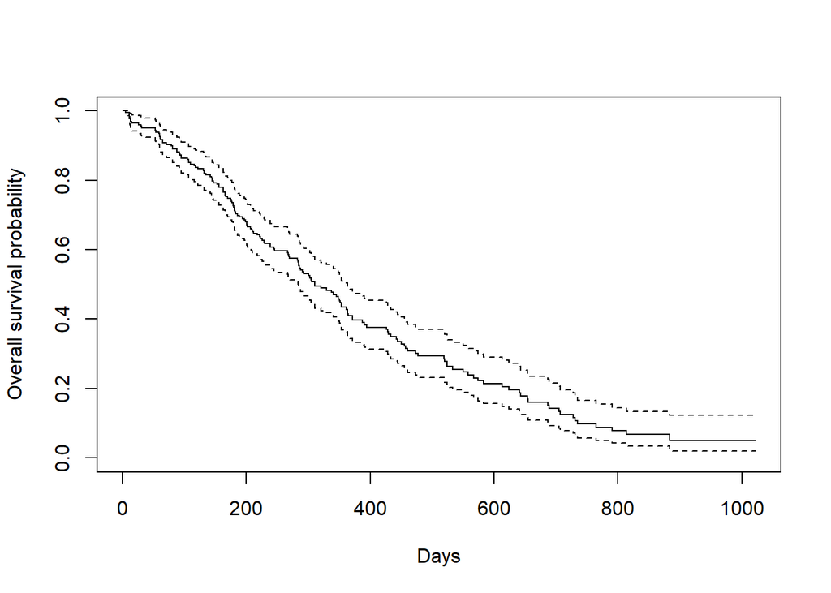

```r
plot(survfit(Surv(time, status) ~ 1, data = lung),
     xlab = "Days",
     ylab = "Overall survival probability")
```

Fancy K-M plot using ggsurvplot

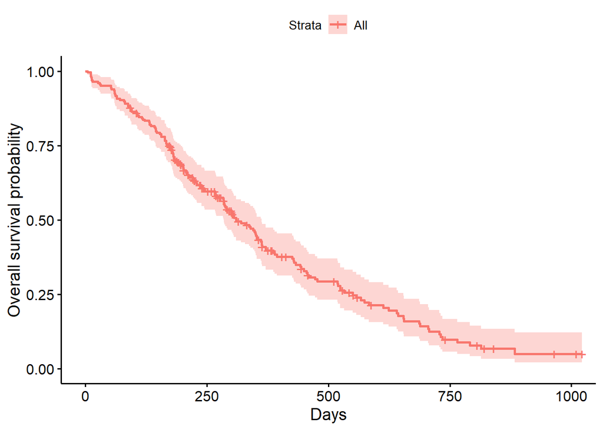

```r
ggsurvplot(
  fit = survfit(Surv(time, status) ~ 1, data = lung),
  xlab = "Days",
  ylab = "Overall survival probability")
```

Probability of surviving beyond a certain number of years 1-month probability of survival 3-month 6-month 1-year

```r
summary(survfit(Surv(time, status) ~ 1, data = lung), times = 30)
```

```
## Call: survfit(formula = Surv(time, status) ~ 1, data = lung)
##
##  time n.risk n.event survival std.err lower 95% CI upper 95% CI
##    30    219      10    0.956  0.0136         0.93        0.983
```

```r
summary(survfit(Surv(time, status) ~ 1, data = lung), times = 90)
```

```
## Call: survfit(formula = Surv(time, status) ~ 1, data = lung)
##
##  time n.risk n.event survival std.err lower 95% CI upper 95% CI
##    90    201      27    0.882  0.0214        0.841        0.925
```

```r
summary(survfit(Surv(time, status) ~ 1, data = lung), times = 180)
```

```
## Call: survfit(formula = Surv(time, status) ~ 1, data = lung)
##
##  time n.risk n.event survival std.err lower 95% CI upper 95% CI
##   180    160      63    0.722  0.0298        0.666        0.783
```

```r
summary(survfit(Surv(time, status) ~ 1, data = lung), times = 365.25)
```

```
## Call: survfit(formula = Surv(time, status) ~ 1, data = lung)
##
##  time n.risk n.event survival std.err lower 95% CI upper 95% CI
##   365     65     121    0.409  0.0358        0.345        0.486
```

95.6%, 88.2%, 72.2%, 40.9% Also see 95% CI lower and upper bounds Median survival time

```r
survfit(Surv(time, status) ~ 1, data = lung)
```

```
## Call: survfit(formula = Surv(time, status) ~ 1, data = lung)
##
##        n events median 0.95LCL 0.95UCL
## [1,] 228    165    310     285     363
```

310 days Compare survival times between groups Difference by sex?

```r
survdiff(Surv(time, status) ~ sex, data = lung)
```

```
## Call:
## survdiff(formula = Surv(time, status) ~ sex, data = lung)
##
##         N Observed Expected (O-E)^2/E (O-E)^2/V
## sex=1 138      112     91.6      4.55      10.3
## sex=2  90       53     73.4      5.68      10.3
##
##  Chisq= 10.3  on 1 degrees of freedom, p= 0.001
```

Cox regression Effect size for one variable (like sex) or multiple variables

```r
coxph(Surv(time, status) ~ sex, data = lung)
```

```
## Call:
## coxph(formula = Surv(time, status) ~ sex, data = lung)
##
##        coef exp(coef) se(coef)      z       p
## sex -0.5310    0.5880   0.1672 -3.176 0.00149
##
## Likelihood ratio test=10.63  on 1 df, p=0.001111
## n= 228, number of events= 165
```

```r
coxph(Surv(time, status) ~ sex + age + wt.loss, data = lung)
```

```
## Call:
## coxph(formula = Surv(time, status) ~ sex + age + wt.loss, data = lung)
##
##               coef  exp(coef)   se(coef)      z      p
## sex     -0.5210319  0.5939074  0.1743541 -2.988 0.0028
## age      0.0200882  1.0202913  0.0096644  2.079 0.0377
## wt.loss  0.0007596  1.0007599  0.0061934  0.123 0.9024
##
## Likelihood ratio test=14.67  on 3 df, p=0.002122
## n= 214, number of events= 152
##    (14 observations deleted due to missingness)
```

gtsummary version of the output Hazard ratio with confidence intervals and p-value in formatted table

```r
coxph(Surv(time, status) ~ sex, data = lung) %>%
  gtsummary::tbl_regression(exp = TRUE)
```

| **Characteristic** | **HR**<sup>1</sup> | **95% CI**<sup>1</sup> | **p-value** |
| --- | --- | --- | --- |
| sex | 0.59 | 0.42, 0.82 | 0.001 |

<sup>1</sup> HR = Hazard Ratio, CI = Confidence Interval

```r
coxph(Surv(time, status) ~ sex + age + wt.loss, data = lung) %>%
  gtsummary::tbl_regression(exp = TRUE)
```

| **Characteristic** | **HR**<sup>1</sup> | **95% CI**<sup>1</sup> | **p-value** |
| --- | --- | --- | --- |
| sex | 0.59 | 0.42, 0.84 | 0.003 |
| age | 1.02 | 1.00, 1.04 | 0.038 |
| wt.loss | 1.00 | 0.99, 1.01 | >0.9 |

<sup>1</sup> HR = Hazard Ratio, CI = Confidence Interval

## Check for assumption that hazards are proportional at each point in time throughout follow-up.

```r
res.cox <- coxph(Surv(time, status) ~ sex + age + wt.loss, data = lung)
res.cox
```

```
## Call:
## coxph(formula = Surv(time, status) ~ sex + age + wt.loss, data = lung)
##
##               coef  exp(coef)   se(coef)      z      p
## sex     -0.5210319  0.5939074  0.1743541 -2.988 0.0028
## age      0.0200882  1.0202913  0.0096644  2.079 0.0377
## wt.loss  0.0007596  1.0007599  0.0061934  0.123 0.9024
##
## Likelihood ratio test=14.67  on 3 df, p=0.002122
## n= 214, number of events= 152
##    (14 observations deleted due to missingness)
```

```r
test.ph <- cox.zph(res.cox)
test.ph
```

```
##          chisq df    p
## sex     2.5489  1 0.11
## age     0.5077  1 0.48
## wt.loss 0.0144  1 0.90
## GLOBAL  3.0051  3 0.39
```

P-value significant? No, p-value not significant - proportional hazards assumption hold (not violated)

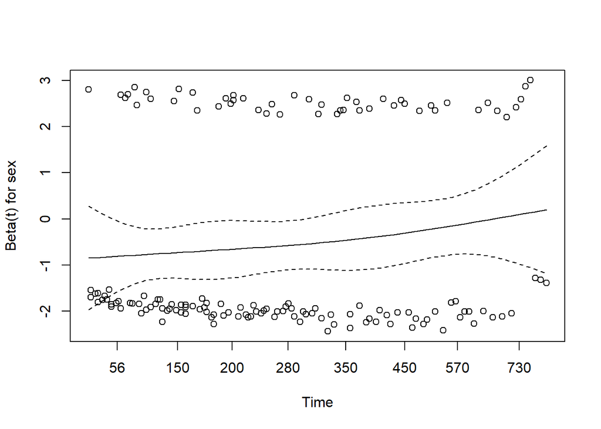

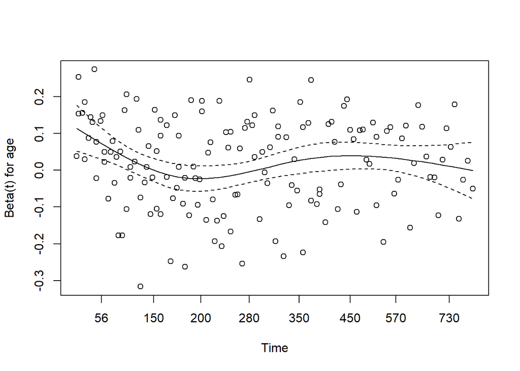

```r
plot(test.ph)
```

[figure not shown]

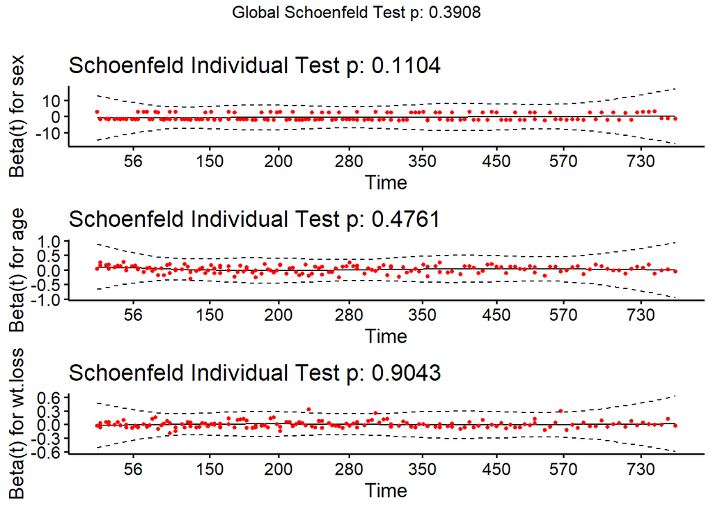

```r
ggcoxzph(test.ph)
```

Deviation from a zero-slope (horizontal) line? No - p-values not significant - proportional hazards assumption holds (not violated)